# **Project 1 ‘Part 4’-‘Regression’**

Sachin Samal (ECU ID 250008)

Nov 12, 2021

### **DATA MINING WITH R**

Here in this part of project, I have decided to perform the regression analysis on my previous dataset from [**Project 1**](https://rpubs.com/sacsam005/808877), [**Project 2**](https://rpubs.com/sacsam005/813688) and [**Project 3**](https://rpubs.com/sacsam005/825478). For this project, I have pulled the data from [**English Premier League Results**](https://www.premierleague.com/results.).

### **WHAT IS REGRESSION?**

**It is a data mining technique used to predict the range of numerical values given in a particular dataset. It is different from association but quite similar to classification. For comparison, you can visit, my [**Project 2**](https://rpubs.com/sacsam005/813688) where I have performed classification on this dataset. Regression might be used to predict the cost of product or service, financial forecasting, environmental modeling and analysis of trends.**

#### **LOADING MY EXCEL DATA INTO R ENVIRONMENT**

```r
library(readxl)
Results <- read_excel("Results.xlsx")
str(Results)
```

```
## tibble [380 × 6] (S3: tbl_df/tbl/data.frame)
##  $ Home_team: chr [1:380] "Arsenal" "Watford" "Chelsea" "Crystal Palace" ...
##  $ Away_team: chr [1:380] "Leicester City" "Liverpool" "Burnley" "Huddersfield Town" ...
##  $ Home_goal: num [1:380] 4 3 2 0 1 0 1 0 0 4 ...
##  $ Away_goal: num [1:380] 3 3 3 3 0 0 0 2 2 0 ...
##  $ Result   : chr [1:380] "H" "D" "A" "A" ...
##  $ Season   : chr [1:380] "2017-2018" "2017-2018" "2017-2018" "2017-2018" ...
```

```r
x<-c(Results$Home_goal)
y<-c(Results$Away_goal)
```

#### **LETS START OUT REGRESSION MINING…**

**Correlation describes the “degree of relationship” between two variables. It ranges from -1 to +1. Negative values indicate that as one variable increases the other variable decreases. Positive values indicate that as one variable increase the other variable increases as well. There are three options to calculate correlation in R, and we will introduce two of them below.**

#### **To get the Correlation R**

```r
cor(Results$Home_goal, Results$Away_goal, method="pearson")
```

```
## [1] -0.1300056
```

**Here, my correlation value is negative that means, when Home goal increases, Away goal decreases, which practically makes sense.**

**I think I’m heading in a right direction.**

We used the ‘Pearson’ correlation method here.
$$r = \frac{\sum_{i=1}^n(x_i-\overline x)(y_i-\overline y )}{(n-1)s_xs_y}$$

**Let x=Home_goal, y=Away_goal, then;**

```r
sx = sd(x)
sy = sd(y)
n = length(x)
xbar = mean(x)
ybar = mean(y)
numerator = mean((x-xbar)*(y-ybar))*n
r = numerator/((n-1)*sx*sy)
r
```

```
## [1] -0.1300056
```

**Now, Lets perform correlation test to futher examine the detail relationship between this two variables:**

```r
cor.test(Results$Home_goal, Results$Away_goal)
```

```
##
##  Pearson's product-moment correlation
##
## data:  Results$Home_goal and Results$Away_goal
## t = -2.5492, df = 378, p-value = 0.01119
## alternative hypothesis: true correlation is not equal to 0
## 95 percent confidence interval:
##  -0.22763028 -0.02979344
## sample estimates:
##        cor
## -0.1300056
```

We already had a negative correlation value of -0.13, which is once again verified through this method.

Also, looks like we have a very small p-value and 95% confidence interval of the correlation.

**Let’s also get the equation of the linear relationship. I just have two variables with numerical values so let me go with one function and see if the intercept in the linear regression is significant.**

```r
lm(Results$Away_goal~Results$Home_goal)
```

```
##
## Call:
## lm(formula = Results$Away_goal ~ Results$Home_goal)
##
## Coefficients:
##       (Intercept)  Results$Home_goal
##            1.3224            -0.1143
```

**The argument `Results$Away_goal~Results$Home_goal` to lm function is a model formula.**

I performed my function as I did **y~x** i.e. **`Results$Away_goal~Results$Home_goal`**. Let’s make some predictions:

```r
fit = lm(y~x)
slope = coef(fit)[2]
intercept = coef(fit)[1]
yhat <- function(xpredict){
  return( slope*xpredict+intercept)
}
yhat(10)
```

```
##         x
## 0.1797584
```

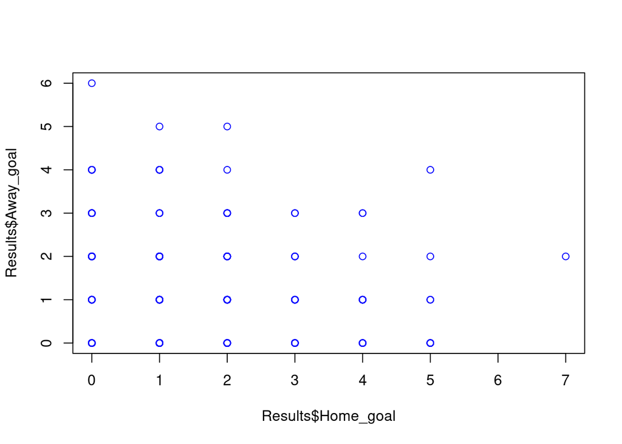

```r
plot(Results$Away_goal~Results$Home_goal, data = Results, col = "blue")
```

```r
Results.num = Results[c("Home_goal", "Away_goal")]
library(PerformanceAnalytics)
```

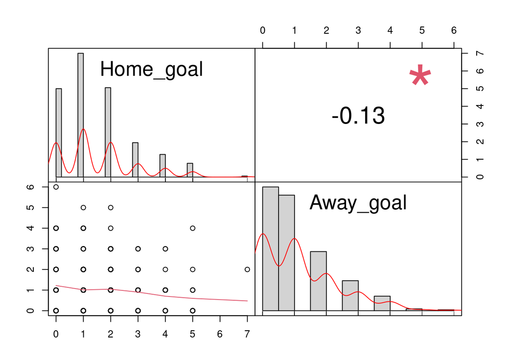

```r
chart.Correlation(Results.num,
                   method="pearson",
                   histogram=TRUE,
                   pch=10)
```

**These statistics vary from –1 to 1, with 0 indicating no correlation, 1 indicating a perfect positive correlation, and –1 indicating a perfect negative correlation. Like other effect size statistics, these statistics are not affected by sample size.**

We have already computed our estimate of the test statistic $r$. Then $t$ is
$$t =
\frac{r\sqrt{n-2}}{\sqrt{1-r^2}}$$

Here the degrees of freedom will be $df=n-2$

```r
t = r*sqrt(n-2)/sqrt(1-r^2)
t
```

```
## [1] -2.549232
```

**This ‘t’ value verifies that we are in a right direction as we already calculated it from the cor.test().**

In case we want to test the slope of the line. We consider the following as the theorectical fit:
$$\hat y = \beta_0+\beta_1x$$

The standard error for the slope is
$$SE_{\beta_1} = \sqrt{\frac{MSE}{\sum\left(x_i-\overline x\right)^2}}$$

Where
$$MSE = \frac{\sum_{i=1}^n\left(y_i-\hat y_i\right)^2}{n-2}$$

$MSE$ is referred to as the mean square error. It adds all the square errors and divides by the adjusted total $(n-2)$ because of the degrees of freedom!

```r
yframe = data.frame('Result' = y)
yhat <- predict(fit,yframe)
MSE = sum((y-yhat)^2)/(n-2)
MSE
```

```
## [1] 1.367358
```

The denominator in the $SE$ computation above is sometimes called the $S_{xx}$ The sum of the squares of $x$.

```r
sxx = sum((x-xbar)^2)
```

Now, we can now calculate the standard error for the slope:

```r
SEslope = sqrt(MSE/sxx)
SEslope
```

```
## [1] 0.04482172
```

In case, I have to look at the intercept, $\beta_0$, it’s standard error is calculated as:

All the value have been computed already. So, the next thing is going to be:

```r
SEintercept = sqrt(MSE*(1/n+xbar^2/sxx))
SEintercept
```

```
## [1] 0.09116391
```

**Now, Let me see the summary before I proceed towards the graph.**

```r
summary(fit)
```

```
##
## Call:
## lm(formula = y ~ x)
##
## Residuals:
##     Min      1Q  Median      3Q     Max
## -1.3224 -1.0938 -0.2081  0.7919  4.6776
##
## Coefficients:
##             Estimate Std. Error t value Pr(>|t|)
## (Intercept)  1.32237    0.09116  14.505   <2e-16 ***
## x           -0.11426    0.04482  -2.549   0.0112 *
## ---
## Signif. codes:  0 '***' 0.001 '**' 0.01 '*' 0.05 '.' 0.1 ' ' 1
##
## Residual standard error: 1.169 on 378 degrees of freedom
## Multiple R-squared:  0.0169, Adjusted R-squared:  0.0143
## F-statistic: 6.499 on 1 and 378 DF,  p-value: 0.01119
```

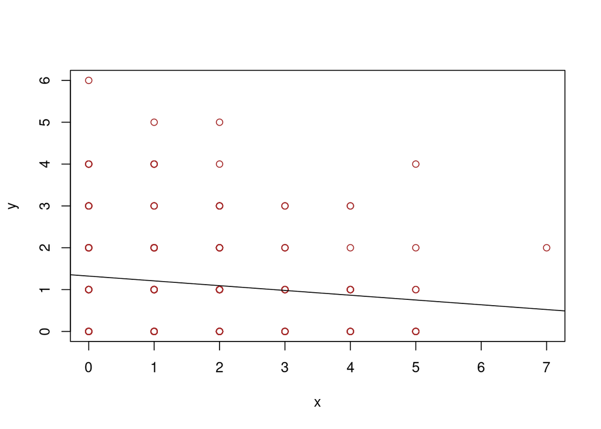

```r
plot(x,y, col='brown')
abline(fit)
```

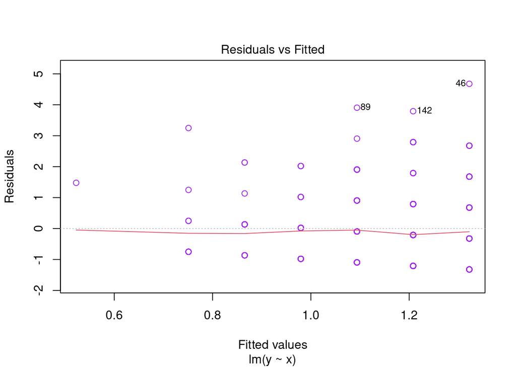

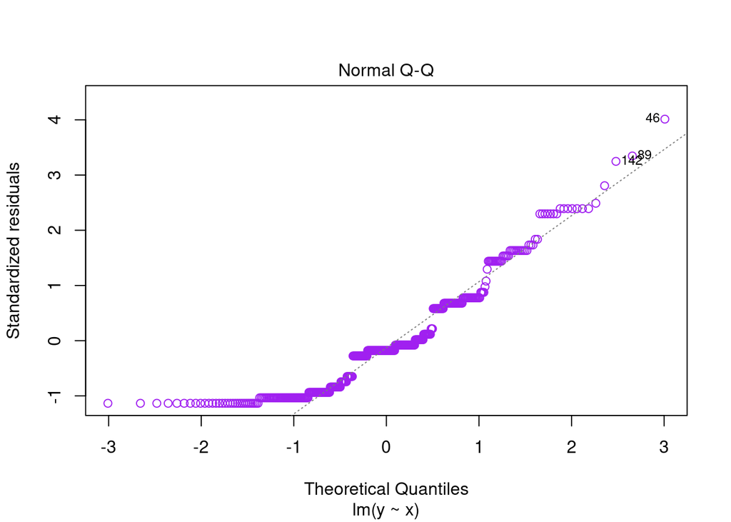

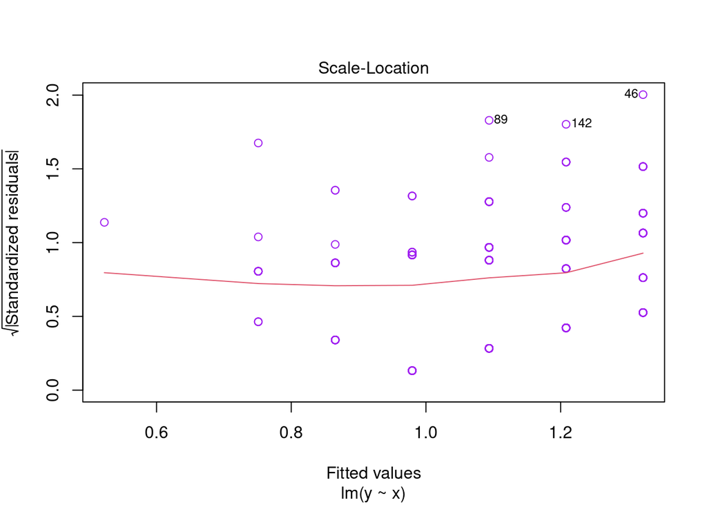

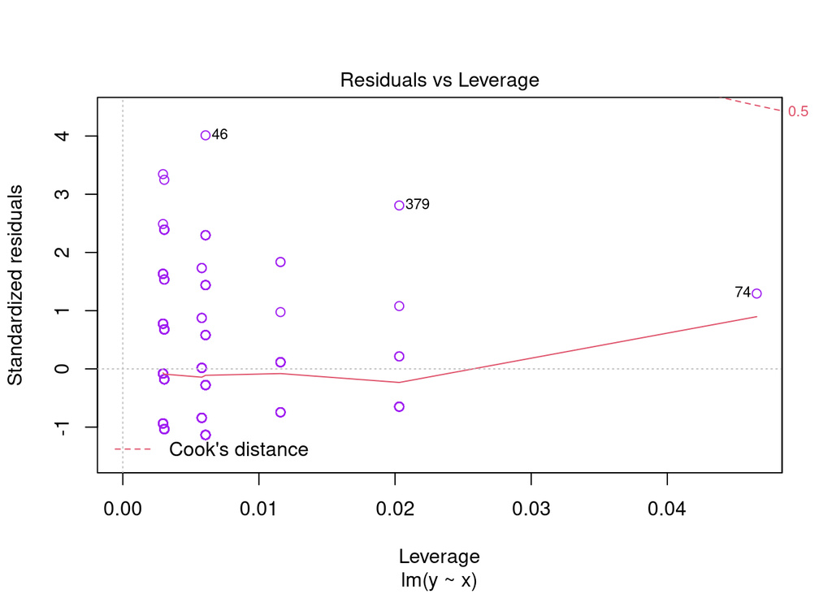

```r
plot(fit, col="purple")
```

**Finally, I’ll conclude with a graph.**

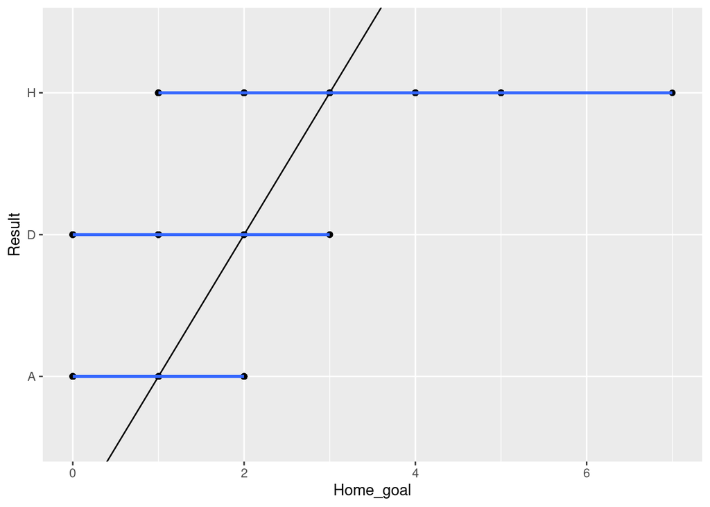

```r
library('ggplot2')
ggplot(data = Results, aes(x = Home_goal, y = Result)) +
  geom_point() +
  geom_abline(slope = 1, intercept = 0) +
  geom_smooth(method = "lm", se = FALSE)
```

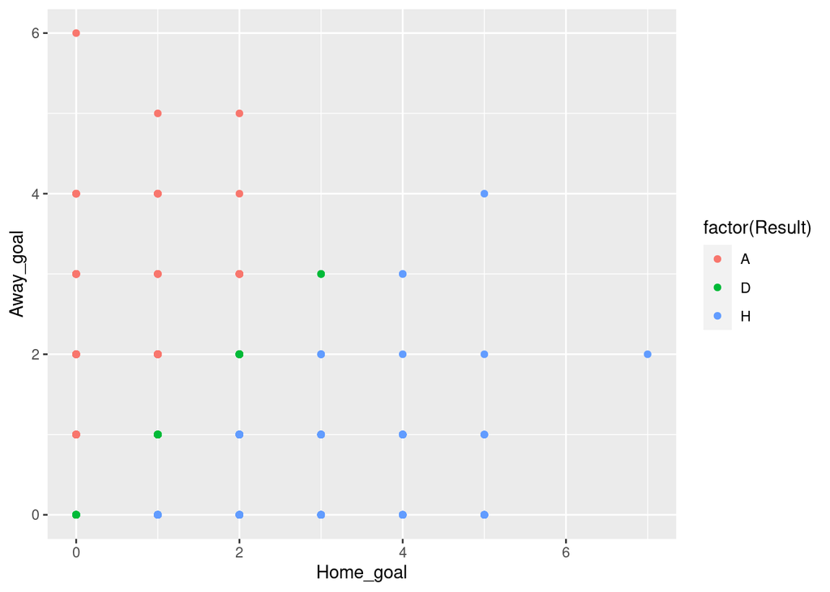

```r
ggplot(data = Results, aes(x = Home_goal, y = Away_goal, color = factor(Result))) +
  geom_point()
```

———————————————————————–END—————————————————————————————————————-